# Assignment #1

## Assignment 1

You only need to write lines of code for each question. When answering questions that ask you to identify or interpret something, the length of your response doesn’t matter. For example, if the answer is just ‘yes,’ ‘no,’ or a number, you can just give that answer without adding anything else.

We will go through comparable code and concepts in the live learning session. If you run into trouble, start by using the help help() function in R, to get information about the datasets and function in question. The internet is also a great resource when coding (though note that no outside searches are required by the assignment!). If you do incorporate code from the internet, please cite the source within your code (providing a URL is sufficient).

Please bring questions that you cannot work out on your own to office hours, work periods or share with your peers on Slack. We will work with you through the issue.

You will need to install PLINK and run the analyses. Please follow the OS-specific setup guide in `SETUP.md`. PLINK is a free, open-source whole genome association analysis toolset, designed to perform a range of basic, large-scale analyses in a computationally efficient manner.

#### Question 1: Data inspection

Before fitting any models, it is essential to understand the data. Use R or bash code to answer the following questions about the `gwa.qc.A1.fam`, `gwa.qc.A1.bim`, and `gwa.qc.A1.bed` files, available at the following Google Drive link: https://drive.google.com/drive/folders/11meVqGCY5yAyI1fh-fAlMEXQt0VmRGuz?usp=drive_link. Please download all three files from this link and place them in `02_activities/data/`.

1. Read the .fam file. How many samples does the dataset contain?

```r
# Loading libraries
library(data.table)
library(dplyr)
library(ggplot2)
```

```r
fam_all <- fread("../data/gwa.qc.A1.fam")
colnames(fam_all) <- c("FID", "IID", "PAT", "MAT", "SEX", "PHENOTYPE")
nrow(fam_all) #4000 samples
```

```
[1] 4000
```

2. What is the ‘variable type’ of the response variable (i.e.Continuous or binary)?

```r
str(fam_all)
```

```
Classes 'data.table' and 'data.frame':  4000 obs. of  6 variables:
 $ FID      : int  0 1 2 3 4 5 6 7 8 9 ...
 $ IID      : chr  "A2001" "A2002" "A2003" "A2004" ...
 $ PAT      : int  0 0 0 0 0 0 0 0 0 0 ...
 $ MAT      : int  0 0 0 0 0 0 0 0 0 0 ...
 $ SEX      : int  1 1 1 1 1 1 1 1 1 1 ...
 $ PHENOTYPE: num  -0.694 1.854 2.083 2.739 1.341 ...
 - attr(*, ".internal.selfref")=<externalptr>
```

```r
summary(fam_all$PHENOTYPE)
```

```
   Min. 1st Qu.  Median    Mean 3rd Qu.    Max.
 -2.175   1.166   1.890   1.877   2.616   5.327
```

```r
# Continuous phenotype
```

3. Read the .bim file. How many SNPs does the dataset contain?

```r
bim_all<- data.table::fread("../data/gwa.qc.A1.bim")
colnames(bim_all) <- c("CHR", "SNP", "CM", "BP", "A1", "A2")
length(unique(bim_all$SNP)) #101083 SNPs
```

```
[1] 101083
```

#### Question 2: Allele Frequency Estimation

1. Load the genotype matrix for SNPs rs1861, rs3813199, rs3128342, and rs11804831 using additive coding. What are the allele frequencies (AFs) for these four SNPs?

```bash
printf "%s\n" rs1861 rs3813199 rs3128342 rs11804831 > ../data/snplist.A1.txt
plink2 --bfile ../data/gwa.qc.A1 \
      --extract ../data/snplist.A1.txt \
      --recode A \
      --out ../data/geno.additive.A1

plink2 --bfile ../data/gwa.qc.A1 --freq --out ../data/gwa_qc_afreq.A1
```

```r
afreq <- fread("../data/gwa_qc_afreq.A1.afreq")
afreq %>% filter(ID %in% c("rs1861", "rs3813199", "rs3128342", "rs11804831"))
```

```
   #CHROM         ID    REF    ALT PROVISIONAL_REF? ALT_FREQS OBS_CT
    <int>     <char> <char> <char>           <char>     <num>  <int>
1:      1  rs3813199      G      A                Y 0.0569126   7942
2:      1 rs11804831      T      C                Y 0.1543410   7924
3:      1  rs3128342      C      A                Y 0.3051210   7928
4:      1     rs1861      C      A                Y 0.0539859   7928
```

```r
# The ALT_FREQS column gives the allele frequencies for the ALT allele, which in this case is the minor allele for all four SNPs. Major allele frequencies can be calculated as 1 - ALT_FREQS.
```

2. What are the minor allele frequencies (MAFs) for these four SNPs?

```r
afreq %>% filter(ID %in% c("rs1861", "rs3813199", "rs3128342", "rs11804831")) %>%
  mutate(MAF = ifelse(ALT_FREQS > 0.5, 1 - ALT_FREQS, ALT_FREQS)) %>%
  select(ID, MAF)
```

```
           ID       MAF
       <char>     <num>
1:  rs3813199 0.0569126
2: rs11804831 0.1543410
3:  rs3128342 0.3051210
4:     rs1861 0.0539859
```

#### Question 3: Hardy–Weinberg Equilibrium (HWE) Test

1. Conduct the Hardy–Weinberg Equilibrium (HWE) test for all SNPs in the .bim file. Then, load the file containing the HWE p-value results and display the first few rows of the resulting data frame.

```bash
plink2 --bfile ../data/gwa.qc.A1 --hardy --out ../data/gwa_qc_hwe.A1
```

```r
hwe <- fread("../data/gwa_qc_hwe.A1.hardy")
head(hwe)
```

```
   #CHROM         ID     A1     AX HOM_A1_CT HET_A1_CT TWO_AX_CT O(HET_A1)
    <int>     <char> <char> <char>     <int>     <int>     <int>     <num>
1:      1  rs3737728      G      A      1713      1841       428  0.462330
2:      1  rs1320565      C      T      3368       589        19  0.148139
3:      1  rs3813199      G      A      3531       428        12  0.107781
4:      1 rs11804831      T      C      2820      1061        81  0.267794
5:      1  rs3766178      T      C      2391      1378       214  0.345970
6:      1  rs3128342      C      A      1927      1655       382  0.417508
   E(HET_A1)         P
       <num>     <num>
1:  0.447932 0.0437892
2:  0.145262 0.2734290
3:  0.107347 1.0000000
4:  0.261040 0.1133540
5:  0.350629 0.4158770
6:  0.424044 0.3302730
```

2. What are the HWE p-values for SNPs rs1861, rs3813199, rs3128342, and rs11804831?

```r
hwe %>% filter(ID %in% c("rs1861", "rs3813199", "rs3128342", "rs11804831")) %>% select(ID, P)
```

```
           ID        P
       <char>    <num>
1:  rs3813199 1.000000
2: rs11804831 0.113354
3:  rs3128342 0.330273
4:     rs1861 0.274719
```

#### Question 4: Genetic Association Test

1. Conduct a linear regression to test the association between SNP rs1861 and the phenotype. What is the p-value?

```r
geno_additive <- fread("../data/geno.additive.A1.raw")
sum(is.na(geno_additive$rs1861_C))   #36 with missing SNP info
```

```
[1] 36
```

```r
sum(is.na(geno_additive$PHENOTYPE))  #0
```

```
[1] 0
```

```r
# drop samples with missing genotype or phenotype data
geno_additive <- geno_additive %>% filter(!is.na(rs1861_C) & !is.na(PHENOTYPE))
summary(glm(PHENOTYPE ~ rs1861_C, data = geno_additive))
```

```
Call:
glm(formula = PHENOTYPE ~ rs1861_C, data = geno_additive)

Coefficients:
            Estimate Std. Error t value Pr(>|t|)
(Intercept)  0.05238    0.09486   0.552    0.581
rs1861_C     0.97382    0.04943  19.703   <2e-16 ***
---
Signif. codes:  0 '***' 0.001 '**' 0.01 '*' 0.05 '.' 0.1 ' ' 1

(Dispersion parameter for gaussian family taken to be 1.005963)

    Null deviance: 4376.1  on 3963  degrees of freedom
Residual deviance: 3985.6  on 3962  degrees of freedom
AIC: 11277

Number of Fisher Scoring iterations: 2
```

```r
# pvalue for rs1861_C is <2e-16 ***
```

2. How would you interpret the beta coefficient from this regression?

```r
# The beta coeficient for rs1861_C is 0.97382. This means that for each additional copy of the C allele at SNP rs1861, the phenotype increases by 0.97382 units, holding all other variables constant.
```

3. Plot the scatterplot of phenotype versus the genotype of SNP rs1861. Add the regression line to the plot.

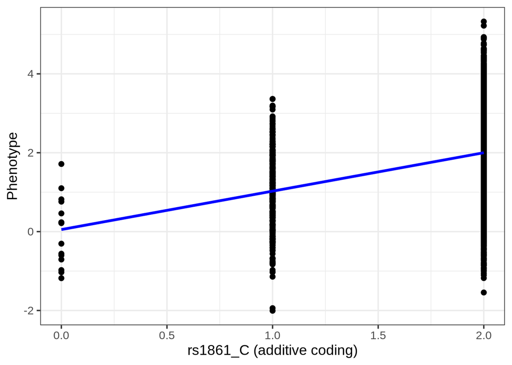

```r
ggplot(geno_additive, aes(x = rs1861_C, y = PHENOTYPE)) + theme_bw(base_size = 14) +
  geom_point() +
  geom_smooth(method = "lm", se = FALSE, color = "blue") +
  labs(x = "rs1861_C (additive coding)", y = "Phenotype")
```

4. Convert the genotype coding for rs1861 to recessive coding.

```r
geno_recessive <- geno_additive # make a copy
geno_recessive[, 7:ncol(geno_recessive)] <- as.data.frame(
  lapply(geno_recessive[, 7:ncol(geno_recessive)], function(x) ifelse(x == 2, 1, 0))
)
```

22. Conduct a linear regression to test the association between the recessive-coded rs1861 and the phenotype. What is the p-value?

```r
summary(glm(PHENOTYPE ~ rs1861_C, data = geno_recessive))
```

```
Call:
glm(formula = PHENOTYPE ~ rs1861_C, data = geno_recessive)

Coefficients:
            Estimate Std. Error t value Pr(>|t|)
(Intercept)  0.99231    0.04945   20.07   <2e-16 ***
rs1861_C     1.00754    0.05224   19.29   <2e-16 ***
---
Signif. codes:  0 '***' 0.001 '**' 0.01 '*' 0.05 '.' 0.1 ' ' 1

(Dispersion parameter for gaussian family taken to be 1.009733)

    Null deviance: 4376.1  on 3963  degrees of freedom
Residual deviance: 4000.6  on 3962  degrees of freedom
AIC: 11292

Number of Fisher Scoring iterations: 2
```

```r
# pvalue for rs1861_C is <2e-16 ***
```

6. Plot the scatterplot of phenotype versus the recessive-coded genotype of rs1861. Add the regression line to the plot.

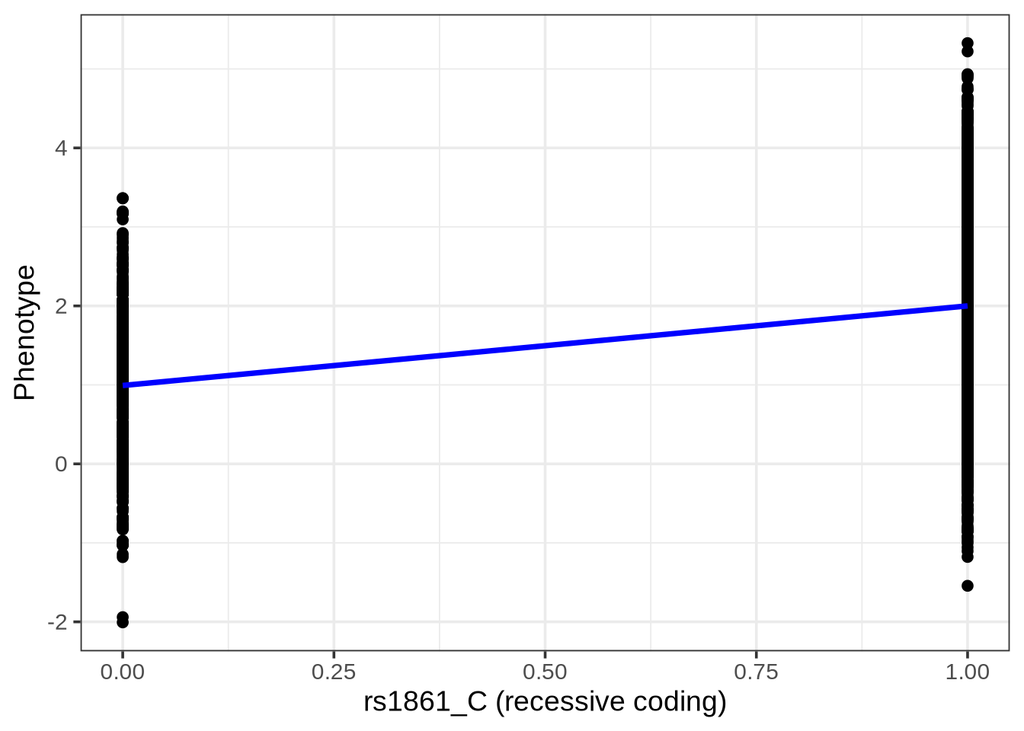

```r
ggplot(geno_recessive, aes(x = rs1861_C, y = PHENOTYPE)) + theme_bw(base_size = 14) +
  geom_point() +
  geom_smooth(method = "lm", se = FALSE, color = "blue") +
  labs(x = "rs1861_C (recessive coding)", y = "Phenotype")
```

7. Which model fits better? Justify your answer.

```r
# The AIC for the additive model is 11277, while the AIC for the recessive model is 11292. The additive model has a slightly lower AIC, indicating that it fits the data better than the recessive model.
```

### Criteria

| Criteria | Complete | Incomplete |
| --- | --- | --- |
| **Data Inspection** | Correct sample/SNP counts and variable type identified. | Missing or incorrect counts or variable type. |
| **Allele Frequency Estimation** | Correct allele and minor allele frequencies computed. | Frequencies missing or wrong. |
| **Hardy–Weinberg Equilibrium Test** | Correct PLINK command and p-value extraction in R. | PLINK command or extraction incorrect/missing. |
| **Genetic Association Test** | Correct regressions, plots, coding, and interpretation. | Regression, plots, or interpretation missing/incomplete. |

### Submission Information

📌 Please review our [Assignment Submission Guide](https://github.com/UofT-DSI/onboarding/blob/main/onboarding_documents/submissions.md) for detailed instructions on how to format, branch, and submit your work. Following these guidelines is crucial for your submissions to be evaluated correctly.

#### Note:

If you like, you may collaborate with others in the cohort. If you choose to do so, please indicate with whom you have worked with in your pull request by tagging their GitHub username. Separate submissions are required.

#### Submission Parameters

- Submission Due Date: `11:59 PM – 16/03/2026`
- Branch name for your repo should be: `assignment-1`
- What to submit for this assignment:
  - Populate this Quarto document (`assignment_1.qmd`).
  - Render the document with Quarto: `quarto render assignment_1.qmd`.
  - Submit both `assignment_1.qmd` and the rendered HTML file `assignment_1.html` in your pull request.
- What the pull request link should look like for this assignment: `https://github.com/<your_github_username>/gen_data/pull/<pr_id>`
  - Open a private window in your browser. Copy and paste the link to your pull request into the address bar. Make sure you can see your pull request properly. This helps the technical facilitator and learning support team review your submission easily.

Checklist:

- Created a branch with the correct naming convention.
- Ensured that the repository is public.
- Reviewed the PR description guidelines and adhered to them.
- Verified that the link is accessible in a private browser window.
- Confirmed that both `assignment_1.qmd` and `assignment_1.html` are included in the pull request.

If you encounter any difficulties or have questions, please don’t hesitate to reach out to our team via our Slack help channel. Our technical facilitators and learning support team are here to help you navigate any challenges.